# Data Analysis Project code

UN data clustering analysis

# Libraries

Load necessary libraries.

```r
library(pdftools)
library(tidyverse)

library(tm)

library(ggplot2)
library(lsa)

library(wordcloud)

library(magrittr)
library(dplyr)
library(ggpubr)

library(proxy)

library(cluster)
library(dendextend)

library(tidytext)
library(topicmodels)
```

# Create a vector

Create a vector data structure in R of the UN PDF file names using the `list.files` function.

```r
all_files <- list.files(pattern = "pdf$")
all_files
```

```
 [1] "46_4_1991.pdf"             "47_4_1992.pdf"
 [3] "48_4_1993.pdf"             "49_4_1994.pdf"
 [5] "50_4_1995.pdf"             "51_4_1996.pdf"
 [7] "52_5_1997.pdf"             "53_7_1998.pdf"
 [9] "54_4_1999.pdf"             "55_10_2000.pdf"
[11] "56_44_2001.pdf"            "57_2_2002.pdf"
[13] "58_7_2003.pdf"             "59_3_2004.pdf"
[15] "60_9_2005.pdf"             "61_10_2006.pdf"
[17] "62_4_2007.pdf"             "63_5_2008.pdf"
[19] "64_3_2009.pdf"             "65_11_2010.pdf"
[21] "66_11_2011.pdf"            "67_6_2012.pdf"
[23] "68_5_2013.pdf"             "69_6_2014.pdf"
[25] "71_8_2016.pdf"             "72_3_2017.pdf"
[27] "73_6_2018.pdf"             "74_3_2019.pdf"
[29] "A_75_592_Add10_E_2020.pdf" "N1529265_2015.pdf"
```

```r
typeof(all_files)
```

```
[1] "character"
```

In the `pdftools` library, the function pdf_text is used to extract text. Using the `lapply` function, the pdf_text function can be applied to each element in the “all_files” vector to then create an object called “UN_files”.

```r
UN_files <- lapply(all_files, pdf_text)
```

```r
length(UN_files)
```

```
[1] 30
```

```r
lapply(UN_files, length)
```

```
[[1]]
[1] 66

[[2]]
[1] 73

[[3]]
[1] 24

[[4]]
[1] 24

[[5]]
[1] 29

[[6]]
[1] 29

[[7]]
[1] 29

[[8]]
[1] 31

[[9]]
[1] 35

[[10]]
[1] 30

[[11]]
[1] 43

[[12]]
[1] 29

[[13]]
[1] 35

[[14]]
```

[output cut: 34 more lines]

```

[[26]]
[1] 24

[[27]]
[1] 53

[[28]]
[1] 60

[[29]]
[1] 75

[[30]]
[1] 57
```

# Text mining

Load the `tm package` and then create a corpus, which is essentially a database for the UN texts.

```r
UN_corpus <- Corpus(URISource(all_files),
               readerControl = list(reader = readPDF))
```

## Term-document matrix

Having created a corpus called `UN_corpus`, a term-document matrix (TDM) can be generated, which stores counts of terms for each document. First, the punctuation marks have to be removed.

```r
UN_corpus <- tm_map(UN_corpus, removePunctuation, ucp = TRUE)
```

```r
UN_corpus.tdm <- TermDocumentMatrix(UN_corpus,
                                   control =
                                     list(stopwords = TRUE,
                                          tolower = TRUE,
                                          stemming = TRUE,
                                          removeNumbers = TRUE,
                                          bounds = list(global = c(3, Inf))))
```

Inspect the UN_corpus term-document matrix:

```r
inspect(UN_corpus.tdm[1:10,])
```

```
<<TermDocumentMatrix (terms: 10, documents: 30)>>
Non-/sparse entries: 80/220
Sparsity           : 73%
Maximal term length: 8
Weighting          : term frequency (tf)
Sample             :
          Docs
Terms      54_4_1999.pdf 63_5_2008.pdf 65_11_2010.pdf 68_5_2013.pdf
  aadd                 6             0              0             0
  ababa                0             0              0             1
  abandon              0             0              1             3
  abba                 0             0              2             1
  abdic                1             1              0             0
  abduct               0             0              0             0
  abdullah             4             4              4             9
  aberr                0             0              0             0
  abhorr               0             0              0             0
  abid                 4             2              1             4
          Docs
Terms      69_6_2014.pdf 71_8_2016.pdf 73_6_2018.pdf 74_3_2019.pdf
  aadd                 0             0             0             0
  ababa                1             1             1             0
  abandon              6             4             5             4
  abba                 0             0             0             0
  abdic                0             0             0             0
  abduct               0             1             0             0
  abdullah             5             6             5             5
  aberr                1             0             1             0
  abhorr               0             2             1             0
  abid                 2             0             3             0
          Docs
Terms      A_75_592_Add10_E_2020.pdf N1529265_2015.pdf
  aadd                            74                 0
  ababa                            0                 5
  abandon                          0                 4
  abba                             0                 0
  abdic                            0                 0
  abduct                           0                 0
  abdullah                         1                 5
  aberr                            0                 0
  abhorr                           0                 0
  abid                             2                 2
```

### Summary statistics

There are a few functions for summary statistics in the `tm package`. For instance, the `findFreqTerms` function can find frequently occurring terms. Words that occur at least 100 times are shown here:

```r
findFreqTerms(UN_corpus.tdm, lowfreq = 100, highfreq = Inf)
```

```
  [1] "abil"           "abl"            "accept"         "access"
  [5] "accord"         "account"        "achiev"         "acknowledg"
  [9] "across"         "act"            "action"         "activ"
 [13] "adapt"          "addit"          "address"        "adopt"
 [17] "advanc"         "affair"         "affect"         "afghanistan"
 [21] "africa"         "african"        "agenc"          "agenda"
 [25] "aggress"        "ago"            "agre"           "agreement"
 [29] "agricultur"     "aid"            "aim"            "allow"
 [33] "almost"         "alon"           "along"          "alreadi"
 [37] "also"           "alway"          "america"        "american"
 [41] "among"          "anniversari"    "announc"        "anoth"
 [45] "appeal"         "appli"          "appreci"        "approach"
 [49] "appropri"       "apv"            "arab"           "area"
 [53] "argentina"      "arm"            "around"         "asia"
 [57] "ask"            "aspir"          "assembl"        "assist"
```

[output cut: 210 more lines]

The counts of these words can be shown in each of the UN report PDF documents:

```r
frequent_terms <- findFreqTerms(UN_corpus.tdm, lowfreq = 100, highfreq = Inf)
as.matrix(UN_corpus.tdm[frequent_terms,])
```

```
                Docs
Terms            46_4_1991.pdf 47_4_1992.pdf 48_4_1993.pdf 49_4_1994.pdf
  abil                       3             3             4             7
  abl                        4             7             1            11
  accept                     7             3             3             9
  access                     0             4             5             5
  accord                     3             2             7             6
  account                    1             5             4             2
  achiev                     5            16            19            22
  acknowledg                 2             5             1             0
  across                     0             5             1             0
  act                        5            10            11            10
  action                    10            17            13            24
  activ                      2             5            20             9
  adapt                      0             3             1             2
  addit                      0             5             0             0
  address                   11            17            16            17
  adopt                     10             8             5             4
  advanc                     4             5             7             6
  affair                     1             2             3             8
  affect                     6             3             1             2
  afghanistan                0             0             0             0
  africa                    12             8            16            29
  african                    7             8             9            13
  agenc                      0             5             4             0
  agenda                     3            33            10            12
  aggress                    2             6             2             0
  ago                        9             5            11             9
  agre                       4             4             3             5
  agreement                  9            15            18            22
  agricultur                 0             0             2             1
  aid                        4             5             5             4
  aim                        4             9             7             3
  allow                      6            11             8             5
  almost                     1             0             8             3
                Docs
Terms            50_4_1995.pdf 51_4_1996.pdf 52_5_1997.pdf 53_7_1998.pdf
  abil                       3             1             5             2
  abl                        9             7            11            10
  accept                    14             3             8             6
```

[output cut: 261 more lines]

```
  afghanistan                    3
  africa                        22
  african                        8
  agenc                         11
  agenda                        63
  aggress                       12
  ago                           35
  agre                          13
  agreement                     37
  agricultur                     2
  aid                            9
  aim                           20
  allow                         21
  almost                         5
 [ reached getOption("max.print") -- omitted 867 rows ]
```

The total counts for the most frequent words can be saved into a matrix. The sum function is subsequently applied across the rows:

```r
frequent_terms.tdm <- as.matrix(UN_corpus.tdm[frequent_terms,])
sort(apply(frequent_terms.tdm, 1, sum), decreasing = TRUE)
```

```
        nation           unit           will          world
          6485           5452           4649           4227
       countri         intern        develop         presid
          3926           3885           3757           3573
       assembl          peopl          state           peac
          3325           3173           3084           3023
          must        general          secur           also
          2968           2721           2577           2093
         right          human            can           year
          2014           2007           1983           1921
        global            new         republ          organ
          1885           1823           1626           1597
           one           need        support         econom
          1531           1518           1504           1496
          work         effort        address         region
          1493           1437           1421           1395
     communiti         govern           time        continu
          1385           1376           1359           1322
        commit        council          polit          today
          1293           1247           1237           1216
      conflict            now         member        respons
          1194           1190           1182           1134
      challeng          chang         cooper           make
          1108           1086           1069           1065
        achiev            war            apv           mani
          1047           1019            999            989
        action           take           like           made
           977            974            966            955
          live           meet         terror         import
           948            948            947            909
       session         effect        sustain           just
           909            902            885            879
           act          order         africa         social
           874            874            865            865
       respect          futur           call           hope
           841            829            822            807
          issu            end            law      democraci
           800            786            783            781
         ensur         believ         togeth           goal
           781            772            772            766
```

[output cut: 395 more lines]

```
           104            104            104            104
 infrastructur       undermin        everyth       function
           104            104            103            103
          pain        qualiti         rememb         coalit
           103            103            103            102
      colombia           core        harmoni           mere
           102            102            102            102
         shown        subject       unpreced      extremist
           102            102            102            101
         imper          incom           lift            old
           101            101            101            101
       strateg       unfortun          claim        commiss
           101            101            100            100
       exercis      experienc          might          prove
           100            100            100            100
```

# Document-term matrix

NB: In a document-term matrix, rows represent documents in the collection and columns represent terms, whereas the term-document matrix is the transpose of DTM. Create document-term matrix:

```r
UN_corpus <- tm_map(UN_corpus, removePunctuation, ucp = TRUE)

dtm = DocumentTermMatrix(UN_corpus,
                         control = list(
                                        stopwords = TRUE,
                                        tolower = TRUE,
                                        removeNumbers = TRUE,
                                        stemming = TRUE,
                                        bounds = list(global = c(3, Inf))))

dtm <- dtm[, names(head(sort(colSums(as.matrix(dtm))), 400))]
dtm <- dtm[, names(sort(colSums(as.matrix(dtm))))]

inspect(dtm)
```

```
<<DocumentTermMatrix (documents: 30, terms: 400)>>
Non-/sparse entries: 1200/10800
Sparsity           : 90%
Maximal term length: 16
Weighting          : term frequency (tf)
Sample             :
                   Terms
Docs                abduct abidjan abomin abyss accru aceh adam adventur
  56_44_2001.pdf         0       0      1     0     0    0    0        0
  64_3_2009.pdf          0       0      1     0     0    0    0        0
  65_11_2010.pdf         0       0      0     0     0    0    0        0
  67_6_2012.pdf          1       1      0     0     0    1    1        0
  68_5_2013.pdf          0       0      0     0     0    0    0        0
  69_6_2014.pdf          0       0      0     1     1    1    0        0
  71_8_2016.pdf          1       0      0     0     1    0    0        0
  73_6_2018.pdf          0       0      0     1     0    0    1        0
  74_3_2019.pdf          0       0      0     0     0    0    0        0
  N1529265_2015.pdf      0       0      0     0     0    0    0        0
                   Terms
Docs                affin affluenc
  56_44_2001.pdf        0        0
  64_3_2009.pdf         0        1
  65_11_2010.pdf        0        0
  67_6_2012.pdf         0        0
  68_5_2013.pdf         0        0
  69_6_2014.pdf         0        0
  71_8_2016.pdf         0        0
  73_6_2018.pdf         0        0
  74_3_2019.pdf         0        0
  N1529265_2015.pdf     0        0
```

## TF-IDF

Term frequency-inverse document frequency (TF-IDF):

```r
UN_dtm <- weightTfIdf(dtm, normalize = TRUE)
dtm.matrix = as.matrix(UN_dtm)

inspect(UN_dtm)
```

```
<<DocumentTermMatrix (documents: 30, terms: 400)>>
Non-/sparse entries: 1200/10800
Sparsity           : 90%
Maximal term length: 16
Weighting          : term frequency - inverse document frequency (normalized) (tf-idf)
Sample             :
                           Terms
Docs                        astonish      asund  conflagr dishonour
  50_4_1995.pdf                    0 0.00000000 0.1186403 0.1186403
  51_4_1996.pdf                    0 0.00000000 0.0000000 0.0000000
  61_10_2006.pdf                   0 0.00000000 0.0000000 0.0000000
  63_5_2008.pdf                    0 0.00000000 0.0000000 0.0000000
  64_3_2009.pdf                    0 0.00000000 0.0000000 0.0000000
  65_11_2010.pdf                   0 0.00000000 0.0000000 0.0000000
  71_8_2016.pdf                    0 0.00000000 0.0000000 0.0000000
  73_6_2018.pdf                    0 0.00000000 0.0000000 0.0000000
  A_75_592_Add10_E_2020.pdf        0 0.08741916 0.0000000 0.0000000
  N1529265_2015.pdf                0 0.00000000 0.0000000 0.0000000
                           Terms
Docs                        disillus farsighted fortysixth indisput lucid
  50_4_1995.pdf             0.000000 0.11864029          0 0.000000     0
  51_4_1996.pdf             0.000000 0.00000000          0 0.000000     0
  61_10_2006.pdf            0.107159 0.00000000          0 0.107159     0
  63_5_2008.pdf             0.000000 0.08741916          0 0.000000     0
  64_3_2009.pdf             0.000000 0.00000000          0 0.000000     0
  65_11_2010.pdf            0.000000 0.00000000          0 0.000000     0
  71_8_2016.pdf             0.000000 0.00000000          0 0.000000     0
  73_6_2018.pdf             0.000000 0.00000000          0 0.000000     0
  A_75_592_Add10_E_2020.pdf 0.000000 0.00000000          0 0.000000     0
  N1529265_2015.pdf         0.000000 0.00000000          0 0.000000     0
                           Terms
Docs                        readjust
  50_4_1995.pdf                    0
  51_4_1996.pdf                    0
  61_10_2006.pdf                   0
  63_5_2008.pdf                    0
  64_3_2009.pdf                    0
  65_11_2010.pdf                   0
  71_8_2016.pdf                    0
  73_6_2018.pdf                    0
  A_75_592_Add10_E_2020.pdf        0
  N1529265_2015.pdf                0
```

# Calculating Distance

The clustering algorithm uses distances to cluster documents.

## Euclidean distance

Use the `dist` function (for matrix distance/ similarity computation) to calculate the Euclidean distance between the documents.

```r
UN_dtm <- as.matrix(UN_dtm)
distMatrix_Eucledian <- dist(UN_dtm, method="euclidean")
print(distMatrix_Eucledian)
```

```
                          46_4_1991.pdf 47_4_1992.pdf 48_4_1993.pdf
47_4_1992.pdf                 0.9112675
48_4_1993.pdf                 0.8210337     0.8483439
49_4_1994.pdf                 0.9420439     0.9455988     0.8925577
50_4_1995.pdf                 0.8705817     0.8781194     0.8199469
51_4_1996.pdf                 0.8677688     0.9142024     0.8121574
52_5_1997.pdf                 0.8360998     0.8648181     0.7937492
53_7_1998.pdf                 0.7885688     0.8450493     0.7320584
54_4_1999.pdf                 0.8410618     0.8526177     0.7995589
55_10_2000.pdf                0.8125429     0.8715905     0.7354872
56_44_2001.pdf                0.7684482     0.8359586     0.7322825
57_2_2002.pdf                 0.8056859     0.8968592     0.7693202
58_7_2003.pdf                 0.9403357     0.9693255     0.8222997
59_3_2004.pdf                 0.8639521     0.9275322     0.8262599
60_9_2005.pdf                 0.7885688     0.8581517     0.7216740
61_10_2006.pdf                0.8518451     0.8971130     0.8121574
62_4_2007.pdf                 0.8711092     0.8695029     0.7995589
63_5_2008.pdf                 0.8186295     0.8180361     0.7621026
64_3_2009.pdf                 0.7589555     0.8016096     0.6893879
65_11_2010.pdf                0.8099005     0.8288391     0.7388228
66_11_2011.pdf                0.8328159     0.8379344     0.7390663
67_6_2012.pdf                 0.7746339     0.7981007     0.6937228
68_5_2013.pdf                 0.7651288     0.7981007     0.7096726
69_6_2014.pdf                 0.7771731     0.8207031     0.6977445
71_8_2016.pdf                 0.7202423     0.7787190     0.6646570
72_3_2017.pdf                 0.9623052     0.9906522     0.9089363
73_6_2018.pdf                 0.7766201     0.8206045     0.7038384
74_3_2019.pdf                 0.7780334     0.7832650     0.6958354
A_75_592_Add10_E_2020.pdf     0.8321615     0.8180361     0.7508115
N1529265_2015.pdf             0.7953882     0.8184728     0.7129382
                          49_4_1994.pdf 50_4_1995.pdf 51_4_1996.pdf
47_4_1992.pdf
48_4_1993.pdf
49_4_1994.pdf
50_4_1995.pdf                 0.9077762
51_4_1996.pdf                 0.9260533     0.8362030
52_5_1997.pdf                 0.8758729     0.8056859     0.7725158
53_7_1998.pdf                 0.8009880     0.7952461     0.7612445
54_4_1999.pdf                 0.8975525     0.8394218     0.8178022
55_10_2000.pdf                0.8833273     0.7968452     0.7766459
```

[output cut: 245 more lines]

```
61_10_2006.pdf
62_4_2007.pdf
63_5_2008.pdf
64_3_2009.pdf
65_11_2010.pdf
66_11_2011.pdf
67_6_2012.pdf
68_5_2013.pdf
69_6_2014.pdf
71_8_2016.pdf
72_3_2017.pdf
73_6_2018.pdf
74_3_2019.pdf
A_75_592_Add10_E_2020.pdf     0.6581944
N1529265_2015.pdf             0.5842347                 0.6661975
```

```r
# NB: For continuous numerical values, use Eucledian distance
```

## Cosine distance

Calculate cosine distance:

```r
UN_tdm <- as.matrix(UN_corpus.tdm)
cosine_dist_mat <- as.matrix(dist(t(UN_tdm), method = "cosine"))

cosine_dist_mat
```

```
                          46_4_1991.pdf 47_4_1992.pdf 48_4_1993.pdf
46_4_1991.pdf                 0.0000000     0.1624813    0.13186320
47_4_1992.pdf                 0.1624813     0.0000000    0.10033695
48_4_1993.pdf                 0.1318632     0.1003370    0.00000000
49_4_1994.pdf                 0.1312336     0.1062629    0.07287630
50_4_1995.pdf                 0.1506979     0.1169703    0.07227100
51_4_1996.pdf                 0.1811646     0.1225187    0.10791221
52_5_1997.pdf                 0.1969399     0.1288881    0.09072109
53_7_1998.pdf                 0.1626289     0.1383064    0.09823607
54_4_1999.pdf                 0.1541192     0.1211882    0.10155346
55_10_2000.pdf                0.1751342     0.1238577    0.09964543
56_44_2001.pdf                0.1691424     0.1351505    0.11562740
57_2_2002.pdf                 0.1990672     0.1432546    0.11501031
58_7_2003.pdf                 0.1794270     0.1207347    0.09522025
59_3_2004.pdf                 0.1832426     0.1206948    0.10919736
60_9_2005.pdf                 0.1864509     0.1325169    0.10700213
61_10_2006.pdf                0.1728616     0.1523436    0.11365099
62_4_2007.pdf                 0.1696658     0.1473843    0.10429962
63_5_2008.pdf                 0.1796573     0.1477062    0.11811014
64_3_2009.pdf                 0.1650609     0.1335478    0.10629806
65_11_2010.pdf                0.1548620     0.1338762    0.10351808
66_11_2011.pdf                0.1535599     0.1211043    0.09365750
67_6_2012.pdf                 0.1537331     0.1175857    0.10812676
68_5_2013.pdf                 0.1619706     0.1098458    0.10106400
69_6_2014.pdf                 0.1662396     0.1343764    0.11448481
71_8_2016.pdf                 0.1762941     0.1513802    0.11804139
72_3_2017.pdf                 0.1947662     0.1643981    0.12463063
73_6_2018.pdf                 0.1632727     0.1284102    0.10739016
74_3_2019.pdf                 0.1717546     0.1268449    0.10812856
A_75_592_Add10_E_2020.pdf     0.2357962     0.1703149    0.17355703
N1529265_2015.pdf             0.1349483     0.1107467    0.08589052
                          49_4_1994.pdf 50_4_1995.pdf 51_4_1996.pdf
46_4_1991.pdf                0.13123363    0.15069785    0.18116463
47_4_1992.pdf                0.10626285    0.11697033    0.12251868
48_4_1993.pdf                0.07287630    0.07227100    0.10791221
49_4_1994.pdf                0.00000000    0.07693988    0.10072250
50_4_1995.pdf                0.07693988    0.00000000    0.09119271
51_4_1996.pdf                0.10072250    0.09119271    0.00000000
52_5_1997.pdf                0.10220114    0.07521232    0.10273042
53_7_1998.pdf                0.09364059    0.10270119    0.11433825
```

[output cut: 286 more lines]

```
61_10_2006.pdf                   0.07571553
62_4_2007.pdf                    0.07070762
63_5_2008.pdf                    0.08044846
64_3_2009.pdf                    0.06724290
65_11_2010.pdf                   0.06945720
66_11_2011.pdf                   0.05185448
67_6_2012.pdf                    0.06012369
68_5_2013.pdf                    0.05151283
69_6_2014.pdf                    0.04778877
71_8_2016.pdf                    0.05568745
72_3_2017.pdf                    0.07310760
73_6_2018.pdf                    0.04523878
74_3_2019.pdf                    0.05505214
A_75_592_Add10_E_2020.pdf        0.12379755
N1529265_2015.pdf                0.00000000
```

The diagonal of the cosine distance matrix `cosine_dist_mat` should be removed, since the distance between a document and itself is neither informative, nor necessary.

```r
diag(cosine_dist_mat) <- NA
cosine_dist <- apply(cosine_dist_mat, 2, mean, na.rm=TRUE)

cosine_dist
```

```
            46_4_1991.pdf             47_4_1992.pdf
               0.16958744                0.13182853
            48_4_1993.pdf             49_4_1994.pdf
               0.10683867                0.11018792
            50_4_1995.pdf             51_4_1996.pdf
               0.11654026                0.13231634
            52_5_1997.pdf             53_7_1998.pdf
               0.12340532                0.10546117
            54_4_1999.pdf            55_10_2000.pdf
               0.10924558                0.11418628
           56_44_2001.pdf             57_2_2002.pdf
               0.10176506                0.10767627
            58_7_2003.pdf             59_3_2004.pdf
               0.09484764                0.09391312
            60_9_2005.pdf            61_10_2006.pdf
               0.10744354                0.10347691
            62_4_2007.pdf             63_5_2008.pdf
               0.09802728                0.09948840
            64_3_2009.pdf            65_11_2010.pdf
               0.09773139                0.09250324
           66_11_2011.pdf             67_6_2012.pdf
               0.08526613                0.08806566
            68_5_2013.pdf             69_6_2014.pdf
               0.08614443                0.08944491
            71_8_2016.pdf             72_3_2017.pdf
               0.09773445                0.11462894
            73_6_2018.pdf             74_3_2019.pdf
               0.08607064                0.09335566
A_75_592_Add10_E_2020.pdf         N1529265_2015.pdf
               0.15163134                0.08161078
```

# Clustering

The R algorithm `hclust` will be used for agglomerative (bottom-up) hierarchical clustering based on Euclidean distance. Hierarchical clustering is computationally inexpensive, as opposed to k-means clustering. Ward’s method is used as the merge rule. Other methods, such as `ward.D2`, `single`, `complete`, `average`, `mcquitty`, `median`, or `centroid` can likewise be used.

The tree can be cut into clusters. These can be determined either arbitrarily or based on one of three methods (the Elbow method, Average silhouette method or Gap statistic method).

[figure not shown]

```r
groups_hierarchical <- hclust(distMatrix_Eucledian, method="ward.D")
clustering <- cutree(groups_hierarchical, 10)
plot(groups_hierarchical,
     main="Hierarchical clustering of UN data",
       cex=0.9, hang=-1)
rect.hclust(groups_hierarchical, 10, border="mediumseagreen")
```

## Hierarchical clustering: “average” linkage method

In hierarchical agglomerative cluster analysis (HAC, for short), there are numerous linkage methods that can be used to generate the different clusters. Another option would be `average`, as shown below.

```r
library(dendextend) # an R package for creating and comparing visually appealing tree diagrams

hclust_average <- hclust(distMatrix_Eucledian, method = "average")
plot(hclust_average)
rect.hclust(hclust_average , k = 10, border = 2:6)
```

[figure not shown]

```r
abline(h = 10, col = 'red')
```

The above dendrogram is produced, whereby each data point eventually merges into a single cluster with the height (or distance) indicated on the y-axis.

### Visualising the tree

This uses the `dendextend` library.

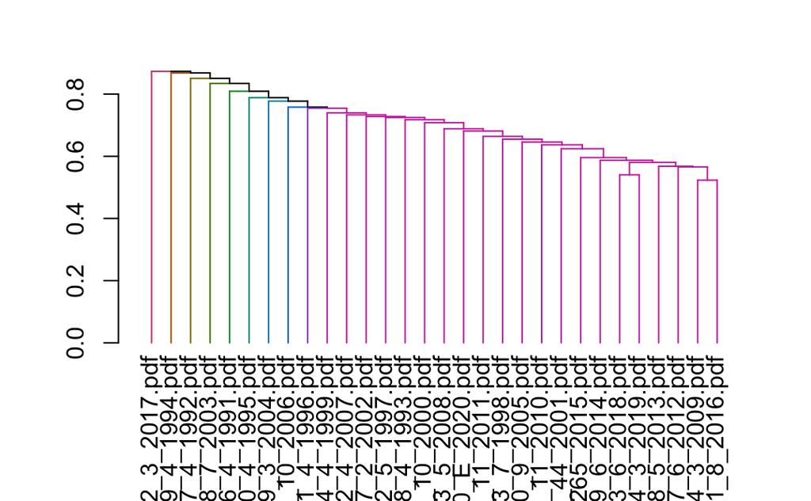

```r
library(dendextend)
average_dend_obj <- as.dendrogram(hclust_average)
average_column_dend <- color_branches(average_dend_obj, k = 10, h = 10)
plot(average_column_dend)
```

## “Centroid” linkage method

In hierarchical agglomerative cluster analysis (HAC, for short), there are numerous linkage methods that can be used to generate the different clusters. Another option would be `centroid`, as shown below.

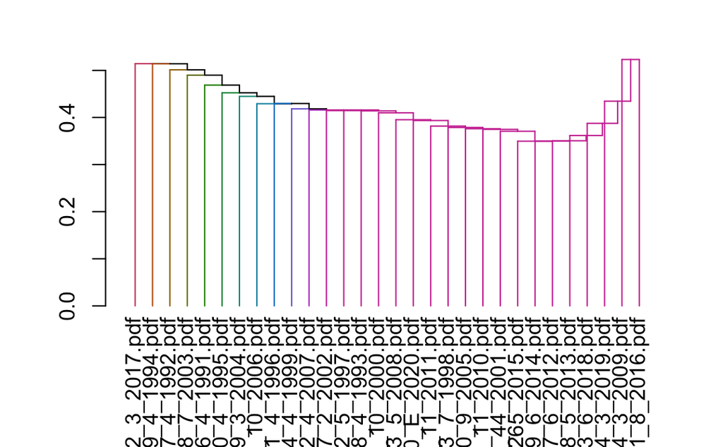

```r
hclust_centroid <- hclust(distMatrix_Eucledian, method = "centroid")
centroid_dend_obj <- as.dendrogram(hclust_centroid)
centroid_column_dend <- color_branches(centroid_dend_obj, k = 12, h = 12)
plot(centroid_column_dend)
```

## “Mcquitty” linkage method

In hierarchical agglomerative cluster analysis (HAC, for short), there are numerous linkage methods that can be used to generate the different clusters. Another option would be `mcquitty`, as shown below.

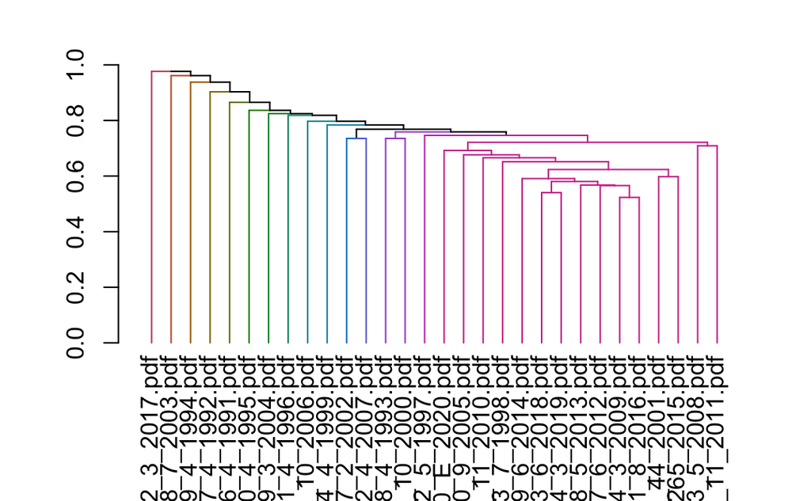

```r
hclust_mcquitty <- hclust(distMatrix_Eucledian, method = "mcquitty")
mcquitty_dend_obj <- as.dendrogram(hclust_mcquitty)
mcquitty_column_dend <- color_branches(mcquitty_dend_obj, k = 15, h = 15)
plot(mcquitty_column_dend)
```

## Divisive hierarchical clustering

Divisive hierarchical clustering is the inverse of hierarchical clustering since it starts off with one cluster containing the whole dataset. Subsequently, the observation with the highest average dissimilarity (in other words, the one farthest from the cluster according to a specific metric) is reassigned to its own cluster. It uses the `cluster` package and the `diana` (DIvisive ANAlysis) function.

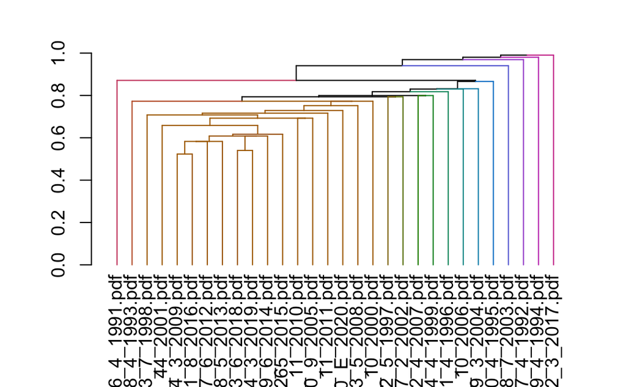

```r
divisive_hclust <- diana(distMatrix_Eucledian, stand=TRUE)

divisive_dend_obj <- as.dendrogram(divisive_hclust)
divisive_column_dend <- color_branches(divisive_dend_obj, k = 15, h = 15)
plot(divisive_column_dend)
```

# LDA: Latent Dirichlet allocation

Latent Dirichlet allocation is a topic modelling algorithm that is based on two guiding principles: + Every document is a mixture of topics; + Every topic is a mixture of words. The package `topicmodels` is used for the LDA method.

```r
lda_text <- LDA(dtm, k=2, method = "VEM", control = NULL)
lda_text
```

```
A LDA_VEM topic model with 2 topics.
```

The 10 most common words in each group topic can be visualising using the `tidytext` Text Mining package. Thus, the “beta” method is used in order to extract the per-topic-per-word probabilities.

```r
lda_topics <- tidy(lda_text, matrix = "beta")
lda_topics
```

| topic | term | beta |
| --- | --- | --- |
| 1 | abduct | 9.289070e-04 |
| 2 | abduct | 4.077049e-03 |
| 1 | abidjan | 2.498327e-03 |
| 2 | abidjan | 2.501680e-03 |
| 1 | abomin | 3.654011e-03 |
| 2 | abomin | 1.341614e-03 |
| 1 | abyss | 2.928881e-03 |
| 2 | abyss | 2.069494e-03 |
| 1 | accru | 4.398932e-03 |
| 2 | accru | 5.938691e-04 |

[output cut: 790 more lines]

The above tibble data frame can then be plotted.

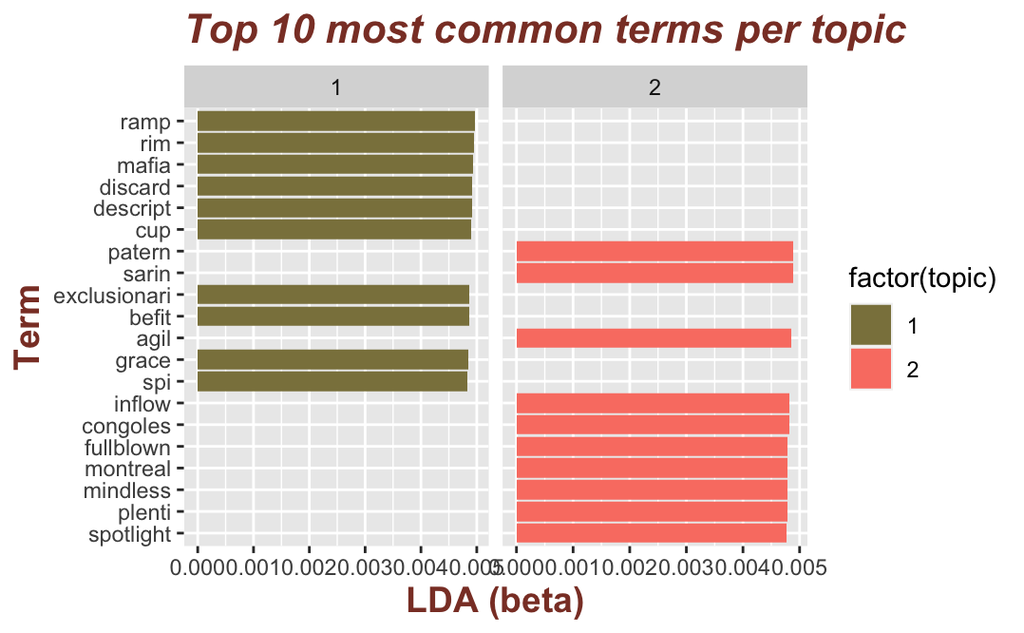

```r
lda_top_terms <- lda_topics %>%
  group_by(topic) %>%
  slice_max(beta, n=10) %>%
  ungroup() %>%
  arrange(topic, -beta)

lda_top_terms %>%
  mutate(term = reorder(term, beta)) %>%
  ggplot(aes(term, beta, fill = factor(topic))) +
  labs(title="Top 10 most common terms per topic",
        x ="Term", y = "LDA (beta)") +
  theme(plot.title=element_text(color="coral4", size=16, face="bold.italic"),
        axis.title.x = element_text(color="coral4", size=14, face="bold"),
        axis.title.y = element_text(color="coral4", size=14, face="bold")) +
  scale_fill_manual(values = c("lightgoldenrod4", "salmon")) +
  geom_col(show.legend = TRUE) +
  facet_wrap(~topic, scales="free_x") +
  coord_flip()
```

## LDA Log ratio

The greatest difference in beta between the two topics can likewise be considered with the help of a log ratio. This analysis relies on the `tidyr` package.

```r
lda_logRatio <- lda_topics %>%
  mutate(topic = paste0("topic", topic)) %>%
  spread(topic, beta) %>%
  filter(topic1 > 0.001 | topic2 > 0.001) %>% # filter for common words that have a beta greater than 1/1000 in at least 1 topic
  mutate(log_ratio = log2(topic2 / topic1))

lda_logRatio
```

| term | topic1 | topic2 | log_ratio |
| --- | --- | --- | --- |
| abduct | 0.0009289070 | 4.077049e-03 | 2.133919313 |
| abidjan | 0.0024983266 | 2.501680e-03 | 0.001935027 |
| abomin | 0.0036540112 | 1.341614e-03 | -1.445511737 |
| abyss | 0.0029288805 | 2.069494e-03 | -0.501071605 |
| accru | 0.0043989317 | 5.938691e-04 | -2.888936296 |
| aceh | 0.0023156445 | 2.685054e-03 | 0.213537581 |
| adam | 0.0030711954 | 1.926639e-03 | -0.672713988 |
| adventur | 0.0025983508 | 2.401276e-03 | -0.113794806 |
| affin | 0.0017717655 | 3.230995e-03 | 0.866791005 |
| affluenc | 0.0020787741 | 2.922823e-03 | 0.491629420 |

[output cut: 390 more lines]

The above tibble data frame can be plotted as follows:

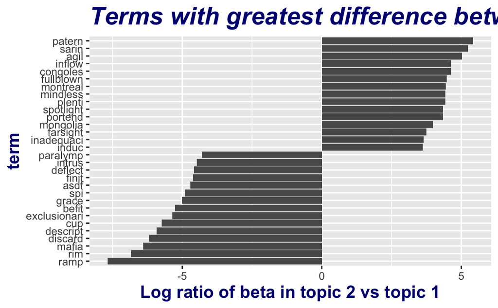

```r
lda_logRatio %>%
  group_by(direction = log_ratio > 0) %>%
  top_n(15, abs(log_ratio)) %>%
  ungroup() %>%
  mutate(term = reorder(term, log_ratio)) %>%
  ggplot(aes(term, log_ratio)) +
  geom_col() +
  labs(title = "Terms with greatest difference between the 2 topics",
       y= "Log ratio of beta in topic 2 vs topic 1") +
  theme(plot.title=element_text(color="navy", size=20, face="bold.italic"),
        axis.title.x = element_text(color="navy", size=14, face="bold"),
        axis.title.y = element_text(color="navy", size=14, face="bold")) +
  scale_fill_manual(values = c("slateblue4", "gold2")) +
  coord_flip()
```

## LDA Document-topic probabilities

Latent Dirichlet Allocation can also model each UN General Assembly report (from 1991 to 2020) as a mixture of topics. In this case, the “gamma” method is used in order to extract the per-document-per-topic probabilities, in other words, it indicates the proportion of the document that consists of words from the assigned topic

```r
lda_documents <- tidy(lda_text, matrix ="gamma")
lda_documents
```

| document | topic | gamma |
| --- | --- | --- |
| 46_4_1991.pdf | 1 | 0.5075382 |
| 47_4_1992.pdf | 1 | 0.4946930 |
| 48_4_1993.pdf | 1 | 0.4699077 |
| 49_4_1994.pdf | 1 | 0.4829373 |
| 50_4_1995.pdf | 1 | 0.5003594 |
| 51_4_1996.pdf | 1 | 0.4789537 |
| 52_5_1997.pdf | 1 | 0.4709850 |
| 53_7_1998.pdf | 1 | 0.5064973 |
| 54_4_1999.pdf | 1 | 0.4896035 |
| 55_10_2000.pdf | 1 | 0.4724441 |

[output cut: 50 more lines]

```r
top_n(lda_documents, 10)
```

| document | topic | gamma |
| --- | --- | --- |
| 57_2_2002.pdf | 1 | 0.5519764 |
| 63_5_2008.pdf | 1 | 0.5243146 |
| 66_11_2011.pdf | 1 | 0.5390604 |
| 67_6_2012.pdf | 1 | 0.5216601 |
| 73_6_2018.pdf | 1 | 0.5382472 |
| 48_4_1993.pdf | 2 | 0.5300923 |
| 52_5_1997.pdf | 2 | 0.5290150 |
| 55_10_2000.pdf | 2 | 0.5275559 |
| A_75_592_Add10_E_2020.pdf | 2 | 0.5281772 |
| N1529265_2015.pdf | 2 | 0.5333467 |

A boxplot can illustrate how well the unsupervised learning algorithm distinguishes between the different topics for each of the UNGA reports.

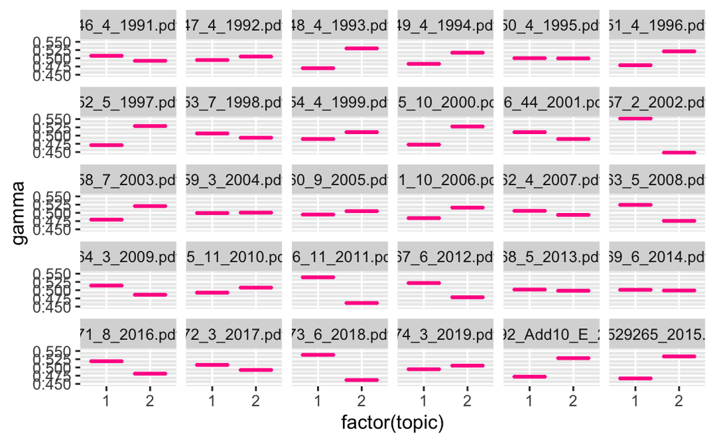

```r
lda_documents %>%
  mutate(title=reorder(document, gamma*topic)) %>%
  ggplot(aes(factor(topic), gamma)) +
  geom_boxplot(fill="gold", color="deeppink1") +
  facet_wrap(~document)
```

# Multidimensional scaling (MDS)

In data analysis, multidimensional scaling is a visual representation of information contained in a distance matrix that reflects the distances or dissimilarities between sets of objects.

```r
# Compute MDS
mds <- UN_tdm %>%
  dist() %>%
  cmdscale() %>%
  as_tibble()
colnames(mds) <- c("Coordinate_1", "Coordinate_2") # unique column names!
```

An MDS plot arranges the points on the graph so that the distances among each pair of points correlates as accurately as possible to the dissimilarity between those two samples.

```r
# Plot MDS
ggscatter(mds, x = "Coordinate_1", y = "Coordinate_2",
          label = rownames(UN_corpus.tdm),
          size = 1,
          repel = TRUE)
```

[output not shown]